# CSCN8010_Lab3

CSCN8010_Lab3

Kosisochukwu Ibe

8940079

Step 1: Load the Data

```python
from sklearn import datasets
diabetes_X, diabetes_y = datasets.load_diabetes(return_X_y=True)
```

Step 2: Data Exploration

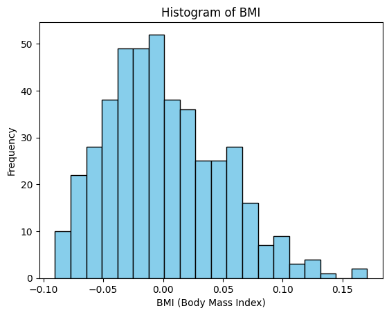

```python
plt.hist(diabetes_X[:, 2], bins=20, color='skyblue', edgecolor='black')
plt.xlabel("BMI (Body Mass Index)")
plt.ylabel("Frequency")
plt.title("Histogram of BMI")
plt.show()
```

Histogram of BMI.

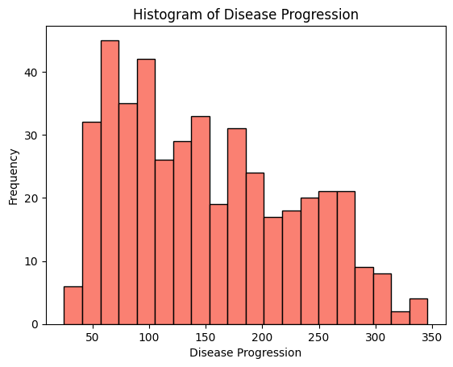

```python
plt.hist(diabetes_y, bins=20, color='salmon', edgecolor='black')
plt.xlabel("Disease Progression")
plt.ylabel("Frequency")
plt.title("Histogram of Disease Progression")
plt.show()
```

Histogram of Disease Progression.

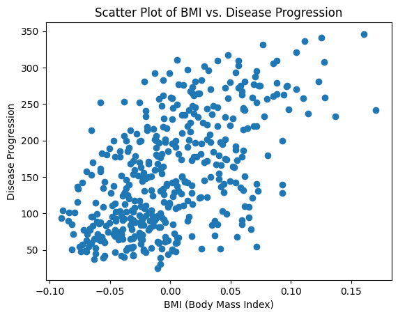

```python
import matplotlib.pyplot as plt

plt.scatter(diabetes_X[:, 2], diabetes_y)
plt.xlabel("BMI (Body Mass Index)")
plt.ylabel("Disease Progression")
plt.title("Scatter Plot of BMI vs. Disease Progression")
plt.show()
```

Exploration using a scatter plot to visualize the relationship between the BMI (body mass index) and the quantitative measure of disease progression.

Step 3: Train-Test Split

```python
from sklearn.model_selection import train_test_split

X_train, X_test, y_train, y_test = train_test_split(diabetes_X[:, 2], diabetes_y, test_size=0.2, random_state=42)
```

The dataset was split 80% for training and 20% for testing randomly with value 42.

Step 6: Fit a Linear Regression Model

```python
from sklearn.linear_model import LinearRegression

# Create a linear regression model
model = LinearRegression()

# Fit the model to the training data
model.fit(X_train.reshape(-1, 1), y_train)
```

```
LinearRegression()
```

Step 7: Report Results

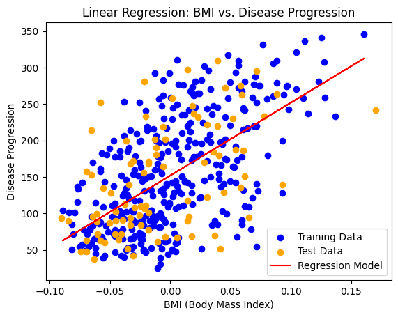

```
Slope (Coefficient): 998.58
Intercept: 152.0
Train Mean Squared Error: 3854.11
Test Mean Squared Error: 4061.83
```

```python
# Plot the training data, test data, and regression line
plt.scatter(X_train, y_train, label='Training Data', color='blue')
plt.scatter(X_test, y_test, label='Test Data', color='orange')
plt.plot(X_train, train_predictions, label='Regression Model', color='red')
plt.xlabel("BMI (Body Mass Index)")
plt.ylabel("Disease Progression")
plt.title("Linear Regression: BMI vs. Disease Progression")
plt.legend()
plt.show()

# Report the linear regression results to 2 decimal places
slope = round(model.coef_[0], 2)
intercept = round(model.intercept_, 2)
train_mse = round(mean_squared_error(y_train, train_predictions), 2)
test_mse = round(mean_squared_error(y_test, test_predictions), 2)

print(f"Slope (Coefficient): {slope}")
print(f"Intercept: {intercept}")
print(f"Train Mean Squared Error: {train_mse:.2f}")
print(f"Test Mean Squared Error: {test_mse:.2f}")
```

The blue dots represent the training data points, and the orange dots represent the test data points. This helps to evaluate how well the model generalizes to unseen data. The red line represents the linear regression model's fit to the data. It shows the linear relationship between BMI and disease progression.

These results provide insights into the linear regression model's performance on the training and test data. The slope represents the change in disease progression associated with a one-unit change in BMI. The intercept is the estimated disease progression when BMI is zero.

The mean squared error (MSE) on both the training and test data measures the quality of the linear regression fit. A lower MSE indicates a better fit. In this case, the model appears to perform slightly better on the training data compared to the test data